# In-Class Activity: Event Studies and Difference-in-Differences

```r
need <- c("tidyverse", "broom", "knitr", "kableExtra", "fixest")
have <- need %in% rownames(installed.packages())
if (any(!have)) install.packages(need[!have])
invisible(lapply(need, library, character.only = TRUE))
```

```r
source('reporting.R')
```

# Overview

In this activity you will work through three related designs:

1. A basic event study with a single treated unit observed before and after a policy.
2. A 2x2 difference-in-differences setup with a treated and a control group.
3. An event-study with leads and lags in a staggered-adoption panel.

The outcome in all three parts is the organ donation rate per million residents. The policy is a donor registration reform meant to increase organ donation. It’s similar to the `socviz` dataset but simulated to make the timing treatment clearer.

## Learning goals

By the end of this activity, you should be able to:

- estimate and interpret a basic DiD model
- explain the parallel trends assumption
- estimate an event-study model with leads and lags
- use pre-treatment coefficients to support parallel trends (or not)

# Part 0. Build the datasets

Let’s generate all of the data up front.

## 0.1 Single-state event study data

```r
set.seed(8300)

single_state <- tibble(
  year = 1995:2010
) %>%
  mutate(
    time = row_number(),
    after = if_else(year >= 2003, 1, 0),
    time_centered = year - 2003,
    donation_rate = 18 +
      0.25 * time +
      2.2 * after +
      0.35 * (time_centered * after) +
      rnorm(n(), 0, 0.8)
  )
```

## 0.2 DiD data

```r
set.seed(8301)

did_data <- expand_grid(
  year = 1995:2010,
  state = c("Control", "Treated")
) %>%
  mutate(
    treated = if_else(state == "Treated", 1, 0),
    after = if_else(year >= 2003, 1, 0),
    donation_rate = 18 +
      1.5 * treated +
      0.35 * (year - 1995) +
      3.0 * (treated * after) +
      rnorm(n(), 0, 0.9)
  )
```

## 0.3 Staggered-adoption panel for leads/lags

```r
set.seed(8302)

adoption_years <- tibble(
  state = c("Arizona", "Colorado", "Florida", "Georgia", "Iowa", "Kansas", "Nevada", "Utah"),
  adopt_year = c(2002, 2004, 2006, 2008, Inf, Inf, 2005, 2007)
)

staggered_data <- expand_grid(
  state = adoption_years$state,
  year = 1998:2010,
  hospital = 1:20
) %>%
  left_join(adoption_years, by = "state") |>
  mutate(
    treated_ever = if_else(is.finite(adopt_year), 1, 0),
    event_time = if_else(is.finite(adopt_year), year - adopt_year, NA_real_),
    treated_now = if_else(is.finite(adopt_year) & year >= adopt_year, 1, 0),
    state_effect = case_when(
      state == "Arizona"  ~  1.2,
      state == "Colorado" ~  0.6,
      state == "Florida"  ~  0.3,
      state == "Georgia"  ~ -0.4,
      state == "Iowa"     ~  0.8,
      state == "Kansas"   ~ -0.2,
      state == "Nevada"   ~  0.1,
      state == "Utah"     ~  1.0
    ),
    common_trend = 0.28 * (year - 1998),
    treatment_effect = if_else(treated_now == 1, 2.5 + 0.15 * pmax(event_time, 0), 0),
    donation_rate = 19 + state_effect + common_trend + treatment_effect + rnorm(n(), 0, 1.1)
  )
```

# Part 1. Basic event study: one state before and after

Let’s say one state introduces a donor registration campaign in 2003 and we see the donation rate before and after.

## Task 1. Visualize the single-state data

Create a scatterplot of `donation_rate` against `year` using the `single_state` data. Add:

- points,
- a dashed vertical line at 2003,
- one fitted line before 2003,
- one fitted line for 2003 and after.

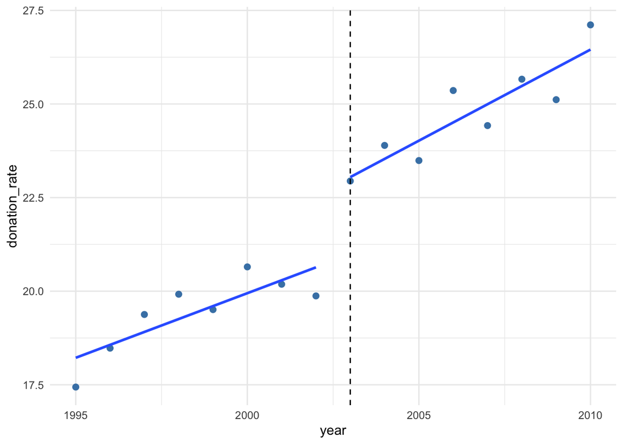

```r
# your code here
ggplot(single_state, aes(x = year, y = donation_rate)) +
  geom_point(color = "steelblue", size = 2) +
  geom_vline(xintercept = 2003, linetype = "dashed") +
  geom_smooth(
    data = subset(single_state, year < 2003),
    method = "lm", se = FALSE) +
  geom_smooth(
    data = subset(single_state, year >= 2003),
    method = "lm", se = FALSE
  ) +
  theme_minimal()
```

## Task 2. Estimate the segmented regression

Estimate:

$$DonationRate_t = \beta_0 + \beta_1 TimeCentered_t + \beta_2 After_t +
\beta_3(TimeCentered_t \times After_t) + \epsilon_t$$
using `single_state`.

```r
# your code here
mod_event <- lm(donation_rate ~ time_centered + after + time_centered:after,
                data = single_state)

mk_coeftab_robust(mod_event, robust_type = "HC1", caption = "single state model results")
```

single state model results

| Term | Estimate | Std. Error (robust) | p value |
| --- | --- | --- | --- |
| Intercept | 20.982 | 0.552 | <0.001 |
| time_centered | 0.345 | 0.111 | 0.009 |
| after | 2.065 | 0.635 | 0.007 |
| time_centered:after | 0.142 | 0.146 | 0.351 |

## Task 3. Interpret the coefficients

In words, what do the following coefficients mean?

1. $\beta_1$: the pre policy trend in donation rates
2. $\beta_2$: the immediate level shift at the time of the reform
3. $\beta_3$: is the change in slope after the reform, relative to the pre period slope

**Your answer:** Was there an immediate jump at the event, and did the trend change afterward?

Yes to immediate jump, no to evidence that the trend changed afterward because the p value on b3 is not significant.

Write 2-4 sentences total.

## Task 4. Why is this design weak for causal inference?

Give one reason why a single-group before/after event study is vulnerable to bias.

**Your answer:**

A single group before/ after comparison can’t separate the policy effect from all the other stuff that changed over time. Maybe donation rates were already rising because of public awareness or other things, we might wrongly attribute those changes to the donor registration reform.

# Part 2. Difference-in-differences

Now we add a control state that did not adopt the reform in 2003.

## Task 5. Visualize the treated and control groups

Make a scatterplot of `donation_rate` against `year`, colored by `state`. Add:

- a dashed vertical line at 2003,
- separate fitted lines for each state before the policy,
- separate fitted lines for each state after the policy.

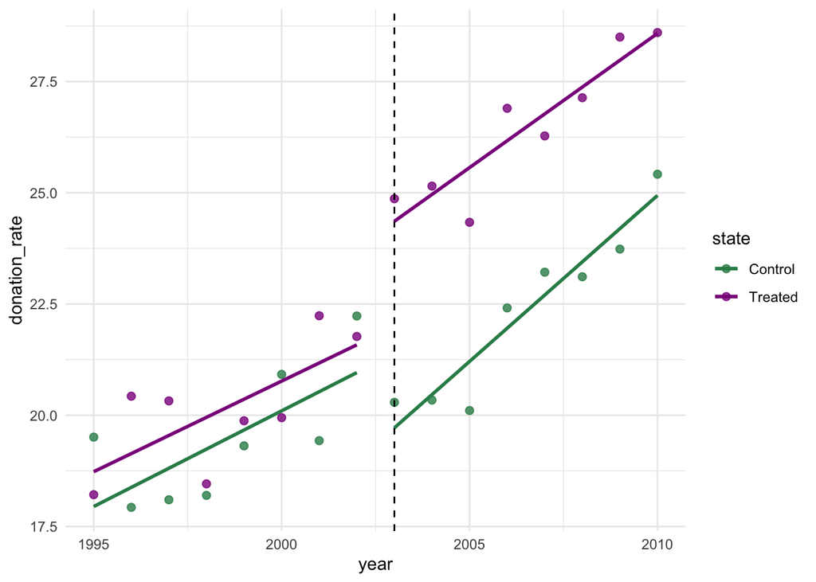

```r
# your code here
ggplot(did_data, aes(x = year, y = donation_rate, color = state)) +
  geom_point(size = 2, alpha = .8) +
  geom_vline(xintercept = 2003, linetype = "dashed") +
  geom_smooth(
    data = subset(did_data, year < 2003),
    method = "lm", se = FALSE) +
  geom_smooth(
    data = subset(did_data, year >= 2003),
    method = "lm", se = FALSE
  ) +
  scale_color_manual(values = c("Control" = "seagreen4", "Treated" = "darkmagenta")) +
  theme_minimal()
```

## Task 6. Estimate the basic DiD model

Estimate:

$$DonationRate_{gt} = \beta_0 + \beta_1 Treated_g + \beta_2 After_t +
\beta_3(Treated_g \times After_t) + \epsilon_{gt}$$

```r
# your code here
mod_did <- lm(donation_rate ~ treated + after + treated:after, data = did_data)

mk_coeftab_robust(mod_did, robust_type = "HC1", caption = "2 x 2 difference in differences model results")
```

2 x 2 difference in differences model results

| Term | Estimate | Std. Error (robust) | p value |
| --- | --- | --- | --- |
| Intercept | 19.454 | 0.528 | <0.001 |
| treated | 0.703 | 0.725 | 0.340 |
| after | 2.875 | 0.862 | 0.002 |
| treated:after | 3.439 | 1.146 | 0.006 |

## Task 7. Compute the “gap of gaps”

Use group means to calculate the DiD estimate manually.

Hint: first compute the mean donation rate by `state` and `after`.

```r
# your code here
did_means <- did_data %>%
  group_by(state, after) %>%
  summarize(mean_rate = mean(donation_rate), .groups = "drop")
```

```r
control_before <- did_means %>% filter(state == "Control", after == 0) %>% pull(mean_rate)
control_after <- did_means %>% filter(state == "Control", after == 1) %>% pull(mean_rate)
treated_before <- did_means %>% filter(state == "Treated", after == 0) %>% pull(mean_rate)
treated_after <- did_means %>% filter(state == "Treated", after == 1) %>% pull(mean_rate)

tibble(
  treated_change = treated_after - treated_before,
  control_change = control_after - control_before,
  did_estimate = treated_change - control_change
)
```

| treated_change | control_change | did_estimate |
| --- | --- | --- |
| 6.313682 | 2.874893 | 3.438789 |

Then answer:

1. What is the treated group’s change from before to after? 6.3
2. What is the control group’s change from before to after? 2.9
3. What is the difference-in-differences estimate? 3.4

**Your answer:** Intercept: average outcome for control group before the treatment B1 is the treatment main effect, the average baseline difference between the treated and control groups before the treatment (pre existing differences) B2 is the average change in the control group’s outcome from before to after the treatment, captures common time trends/ shocks affecting both groups B3 is the DiD term, the difference in changes

## Task 8. Parallel trends

Look at your plot from Task 5.

Do the pre-treatment trends look roughly parallel? Based on the simulation, does the parallel trends assumption seem plausible here?

**Your answer:** The pre treatment trends look roughly parallel and the parallel trends assumption seems plausible here because the data were simulated with the same underlying time slope for both groups before the reform.

# Part 3. Event-study leads and lags

Now we’ll go to a staggered-adoption setting where different states adopt at different times and some never adopt.

## Task 9. Create event-time indicators and estimate an event study

We’ll keep only event times between -4 and 4 for treated states, and keep never-treated states as controls.

```r
event_window <- staggered_data %>%
  filter((treated_ever == 1 & event_time >= -4 & event_time <= 4) | treated_ever == 0)

event_window <- event_window %>%
  mutate(
    event_time_treated = if_else(treated_ever == 1, as.character(event_time), NA_character_),
    event_time_treated = factor(event_time_treated),
    event_time_treated = relevel(event_time_treated, ref = "-1")
  )
```

Now create a factor for the treated units’ event times only, using `-1` as the omitted reference period. One convenient way is to make a variable that is `"never"` for never-treated states and the event time for treated states, then interact that with treatment status.

Estimate a model with:

- state fixed effects,
- year fixed effects,
- event-time interactions for treated states.

You may use a model of the form:

$$DonationRate_{st} = \alpha_s + \lambda_t + \sum_{k \neq -1}\beta_k
\left(1\{event\_time = k\} \times treated\_ever_s\right) + \epsilon_{st}$$

```r
# your code here
mod_es <- lm(donation_rate ~ factor(state) + factor(year) + treated_ever:event_time_treated, data = event_window)

mk_coeftab_robust(mod_es, robust_type = "HC1", caption = "event study with leads and lags")
```

event study with leads and lags

| Term | Estimate | Std. Error (robust) | p value |
| --- | --- | --- | --- |
| Intercept | 21.177 | 1.182 | <0.001 |
| factor(state)Colorado | -1.193 | 0.347 | <0.001 |
| factor(state)Florida | -2.163 | 0.651 | <0.001 |
| factor(state)Georgia | -3.491 | 0.960 | <0.001 |
| factor(state)Nevada | -2.181 | 0.502 | <0.001 |
| factor(state)Utah | -1.756 | 0.789 | 0.026 |
| factor(year)1999 | 0.205 | 0.393 | 0.601 |
| factor(year)2000 | 1.150 | 0.419 | 0.006 |
| factor(year)2001 | 1.721 | 0.546 | 0.002 |
| factor(year)2002 | 2.266 | 0.688 | 0.001 |
| factor(year)2003 | 2.998 | 0.830 | <0.001 |
| factor(year)2004 | 3.438 | 0.984 | <0.001 |
| factor(year)2005 | 3.876 | 1.151 | <0.001 |
| factor(year)2006 | 4.404 | 1.277 | <0.001 |
| factor(year)2007 | 5.273 | 1.476 | <0.001 |
| factor(year)2008 | 5.697 | 1.599 | <0.001 |
| factor(year)2009 | 6.321 | 1.747 | <0.001 |
| factor(year)2010 | 6.736 | 1.912 | <0.001 |
| treated_ever:event_time_treated-1 | -1.830 | 0.696 | 0.009 |
| treated_ever:event_time_treated-2 | -1.390 | 0.855 | 0.104 |
| treated_ever:event_time_treated-3 | -1.225 | 1.012 | 0.226 |
| treated_ever:event_time_treated-4 | -0.759 | 1.169 | 0.516 |
| treated_ever:event_time_treated0 | 0.499 | 0.543 | 0.358 |
| treated_ever:event_time_treated1 | 0.498 | 0.390 | 0.202 |
| treated_ever:event_time_treated2 | 0.297 | 0.250 | 0.235 |

## Task 10. Extract and plot the lead/lag coefficients

Create a tidy results table of the event-time interaction terms, then plot:

- event time on the x-axis,
- coefficient estimate on the y-axis,
- a horizontal line at 0,
- a vertical line at 0,
- points and 95% confidence intervals.

```r
# your code here
es_results <- tidy(mod_es) %>%
  filter(str_detect(term, "treated_ever:event_time_treated")) %>%
  mutate(
    event_time = str_remove(term, "treated_ever:event_time_treated") %>% as.numeric()
  ) %>%
  select(event_time, estimate, std.error, statistic, p.value)

es_results <- bind_rows(
  tibble(
    event_time = -1,
    estimate = 0,
    std.error = 0,
    statistic = NA_real_,
    p.value = NA_real_
  ),
  es_results
) %>%
  arrange(event_time) %>%
  mutate(
    period = case_when(
      event_time < 0 ~ "Lead",
      event_time == 0 ~ "Event",
      TRUE ~ "Lag"
    )
  )
```

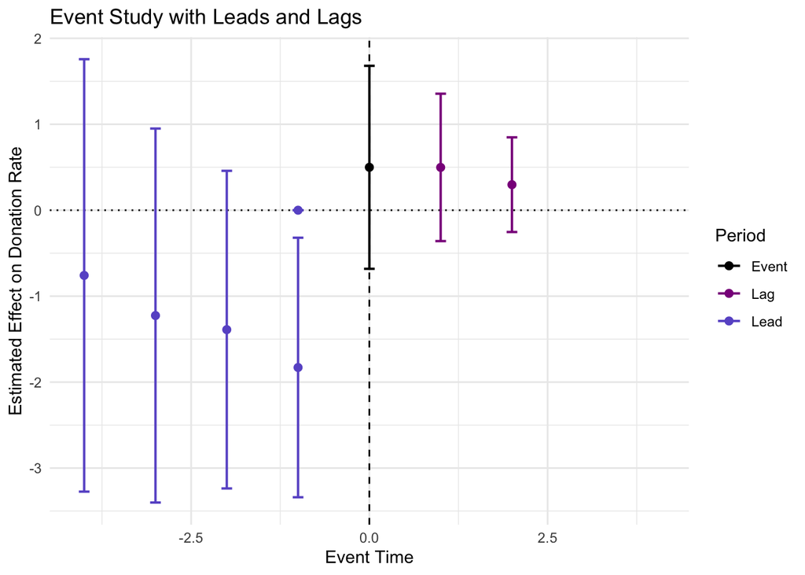

```r
ggplot(es_results, aes(x = event_time, y = estimate, color = period)) +
  geom_hline(yintercept = 0, linetype = "dotted") +
  geom_vline(xintercept = 0, linetype = "dashed") +
  geom_point(size = 2) +
  geom_errorbar(
    aes(
      ymin = estimate - 1.96 * std.error,
      ymax = estimate + 1.96 * std.error
    ),
    width = 0.15,
    linewidth = 0.7
  ) +
  scale_color_manual(
    values = c("Lead" = "slateblue", "Event" = "black", "Lag" = "darkmagenta")
  ) +
  labs(
    title = "Event Study with Leads and Lags",
    x = "Event Time",
    y = "Estimated Effect on Donation Rate",
    color = "Period"
  ) +
  theme_minimal()
```

Then answer:

1. Are the lead coefficients mostly close to zero?
2. What do the lag coefficients suggest about the treatment effect after adoption?
3. How does this event-study setup relate back to the basic DiD model?

**Your answer:**

the lag coefficients should become positive after treatment, which indicates higher donation rates after the reform.

It relates back to basic DiD because the single DiD interaction coefficient is replaced with a sequence of those event time specific interaction coefficients. DiD is an average post treatment effect while having a beta for each period shows the path over time.

We can say what should be the case because the data are simulated.

# Wrap-up

In 3-5 sentences, summarize the differences among:

- a basic event study,
- a 2x2 DiD design,
- an event-study with leads and lags.

**Your answer:**

A basic naive event study compares one unit before and after an event but it can’t rule out other changes over time. A 2x2 DiD design makes this better because it adds a control and differences out common time changes (relies on parallel trends assumption). An event study with leads and lags is a more flexible version of DiD that estimates a separate treatment effect for each period relative to a baseline and uses pre treatment coefficients to check support for the parallel trends assumption.